## Introduction to generalised linear mixed-effects models (GLMMMs)

Recall module 3 when we covered fitting linear models with random effects (`lmer`). The fixed effects and random effects were specified via the model formula. Now we’ve covered GLMs we can include random effects here too and fit GLMMs!

**Recall**

- **Fixed effects:** terms (parameters) in a statistical model which are fixed, or non-random, quantities (e.g., *treatment* group’s mean response). For the same *treatment*, we expect this quantity to be the same from experiment to experiment.
- **Random effects:** terms (parameters) in a statistical model which are considered as random quantities or variables (e.g., block id). Specifically, terms whose levels are a representative sample from a population, and where the variance of the population is of interest should be allocated as random. Setting a block as a random effect allows us to infer variation between blocks as well as the variation between experimental units within blocks.

### Fitting a GLMM

The authors of [this paper](https://pubmed.ncbi.nlm.nih.gov/31150625/) transplanted gut microbiota from human donors with Autism Spectrum Disorder (ASD) or typically developing (TD) controls into germ-free mice. Faecal samples were collected from three TD and five ASD donors and were used to colonise GF male and female mice from strain C57BL/6LJ. Individuals colonized by the same donor were allowed to breed. Adult offspring mice were behavior tested; tests included marble burying (MB), open-field testing (OFT), and ultrasonic vocalization (USV).

```r
library(tidyverse)
data <- read_csv("https://raw.githubusercontent.com/STATS-UOA/databunker/master/data/autism.csv")
data
```

```
## # A tibble: 206 × 3
##    Donor   Treatment MB_buried
##    <chr>   <chr>         <dbl>
##  1 C1      NT Female         3
##  2 C1      NT Female         8
##  3 C1      NT Female         1
##  4 C1      NT Female         3
##  5 C1      NT Male           2
##  6 C1      NT Male           6
##  7 C1      NT Male           4
##  8 C1      NT Male           2
##  9 C1      NT Female         9
## 10 A24-new ASD Male          7
## # … with 196 more rows
```

We should separate out the treatment values:

```r
mice <- data %>%
  separate(., col = Treatment, into = c("Diagnosis", "Sex"))
mice
```

```
## # A tibble: 206 × 4
##    Donor   Diagnosis Sex    MB_buried
##    <chr>   <chr>     <chr>      <dbl>
##  1 C1      NT        Female         3
##  2 C1      NT        Female         8
##  3 C1      NT        Female         1
##  4 C1      NT        Female         3
##  5 C1      NT        Male           2
##  6 C1      NT        Male           6
##  7 C1      NT        Male           4
##  8 C1      NT        Male           2
##  9 C1      NT        Female         9
## 10 A24-new ASD       Male           7
## # … with 196 more rows
```

**Recall, using `lmer` to fit a LMM**

```r
lmer <- lmerTest::lmer(MB_buried ~ Sex * Diagnosis + (1|Donor), data = mice)
car::Anova(lmer, type = 2)
```

```
## Analysis of Deviance Table (Type II Wald chisquare tests)
##
## Response: MB_buried
##                Chisq Df Pr(>Chisq)
## Sex           3.6329  1   0.056648 .
## Diagnosis     8.6944  1   0.003192 **
## Sex:Diagnosis 2.9745  1   0.084588 .
## ---
## Signif. codes:  0 '***' 0.001 '**' 0.01 '*' 0.05 '.' 0.1 ' ' 1
```

But is the constant error variance appropriate? Below we plot the model residuals.

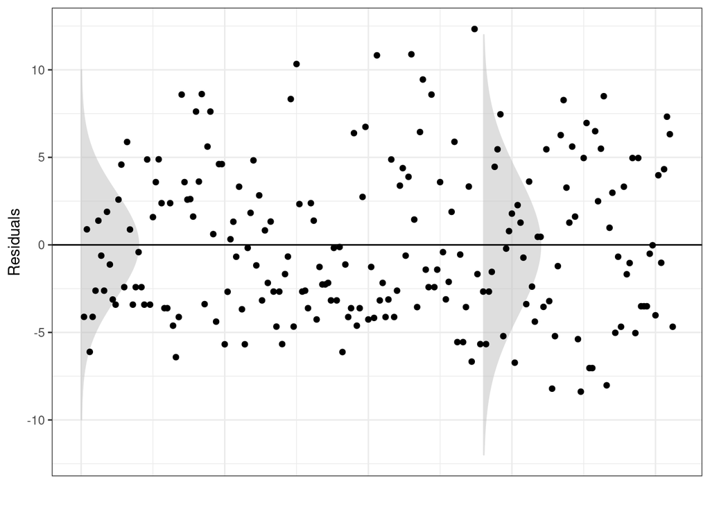

#### Using `glmer`

```r
glmer <- lme4::glmer(MB_buried ~ Sex * Diagnosis + (1|Donor), data = mice, family = poisson(link = "log"))
car::Anova(glmer, type = 2)
```

```
## Analysis of Deviance Table (Type II Wald chisquare tests)
##
## Response: MB_buried
##                 Chisq Df Pr(>Chisq)
## Sex            9.9452  1  0.0016127 **
## Diagnosis     10.5836  1  0.0011410 **
## Sex:Diagnosis 12.5904  1  0.0003877 ***
## ---
## Signif. codes:  0 '***' 0.001 '**' 0.01 '*' 0.05 '.' 0.1 ' ' 1
```

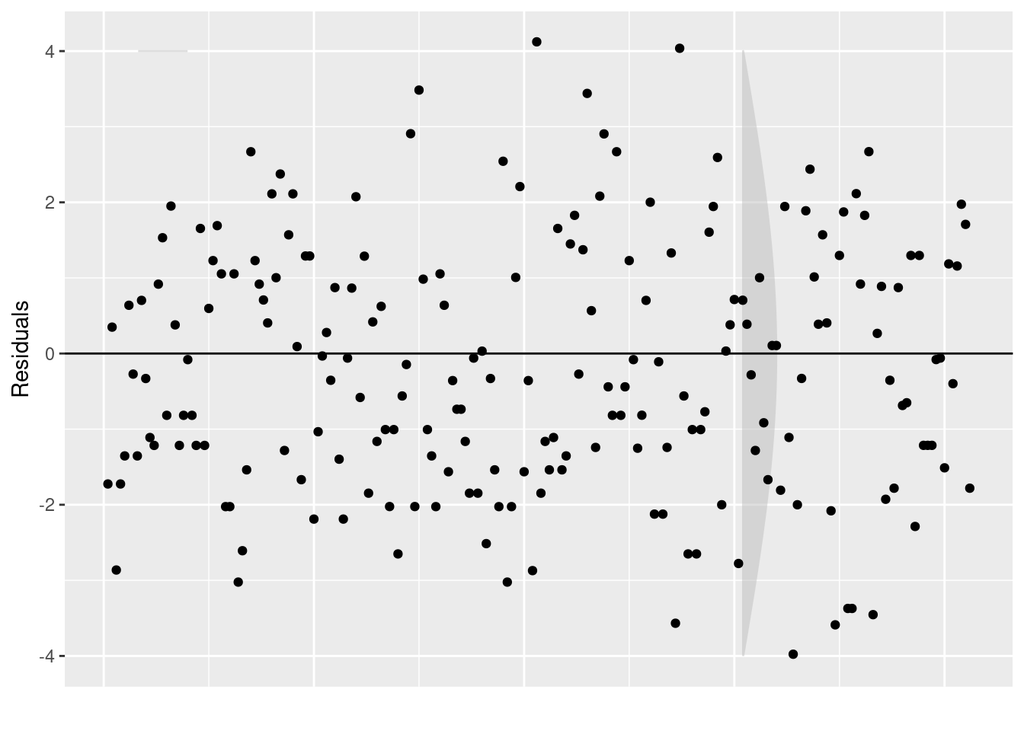